# R: Tidyverse

24 septembre 2019

## Manifeste

## Approche complète de l’analyse de données

Données bien rangées (*tidy*)

Enchaînement des opérations (`%>%` de *magrittr*, `+` de *ggplot2*)

Programmation fonctionnelle (pas orientée objet), optimisée pour les utilisateurs (lisibilité plutôt que performance)

```r
library("tidyverse")
vignette("manifesto", package = "tidyverse")
```

Ensemble de packages, appelés par *tidyverse*

## Données rectangulaires

Modèle du data frame : une ligne par observation, une colonne par attribut.

Dataframe optimisé : `tibble`

Documentation : `vignette("tibble", package="tibble")`

```r
ggplot2::diamonds
```

```
## # A tibble: 53,940 x 10
##   carat cut   color clarity depth table price
##   <dbl> <ord> <ord> <ord>   <dbl> <dbl> <int>
## 1 0.23  Ideal E     SI2      61.5    55   326
## 2 0.21  Prem~ E     SI1      59.8    61   326
## 3 0.23  Good  E     VS1      56.9    65   327
## 4 0.290 Prem~ I     VS2      62.4    58   334
## 5 0.31  Good  J     SI2      63.3    58   335
## # ... with 5.394e+04 more rows, and 3 more
## #   variables: x <dbl>, y <dbl>, z <dbl>
```

## Pipe (tuyau)

Le package *magrittr* introduit le pipe `%>%` (`Ctrl + Shift + m`)

[figure not shown]

[figure not shown]

Modèle du pipeline de la programmation système repris par la bioinformatique

## Pipe (tuyau)

Exemple :

```r
1:10 %>% sum
```

```
## [1] 55
```

Principe : les données résultant d’un calcul sont passées à la fonction suivante.

Enchainement :

```r
1:10 %>% sqrt %>% sum
```

```
## [1] 22.46828
```

Code plus lisible que `sum(sqrt(1:10))`

## Autres opérateurs

Tuyau avec retour :

```r
library("magrittr")
x <- c(4, 9)
x %<>% sqrt
x
```

```
## [1] 2 3
```

Embranchement :

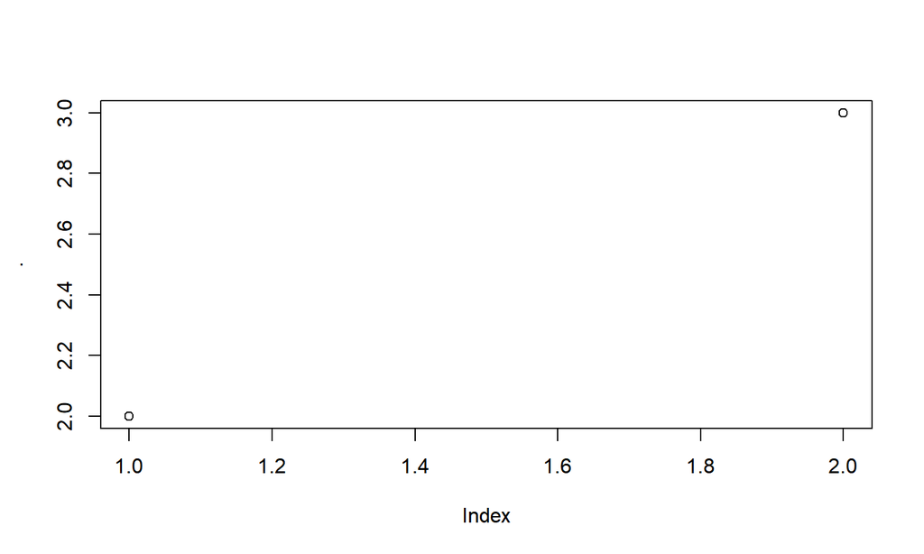

```
## [1] 5
```

```r
x %T>% plot %>% sum
```

## Autres opérateurs

Exposition :

```r
diamonds %$% mean(price)
```

```
## [1] 3932.8
```

Le tuyau de base est accessible sans charger `magrittr`

Les autres sont moins utiles

## Méthode de travail

Bagarre (*Wrangling*) :

- Importation des données
- Rangement (*Tidy*)
- Transformation

Visualisation

Modélisation : non traitée ici. [A lire](http://r4ds.had.co.nz/model-intro.html).

Communication : RMarkdown et sorties graphiques. Lire :

- [Graphics for communication](http://r4ds.had.co.nz/graphics-for-communication.html)
- [Top 50 ggplot2 Visualizations](http://r-statistics.co/Top50-Ggplot2-Visualizations-MasterList-R-Code.html)

## Bagarre

## Package *readr*

Lecture de fichiers texte variés.

Importation dans un tibble.

[Référence](http://r4ds.had.co.nz/data-import.html#data-import)

## Fichier csv

Fonctions `read_csv()` et `read_csv2()`

Remplacent `read.csv()` et `read.csv2()` de base

Plus rapide que les fonctions originales.